# Water, and its Factors in different Countries

- Ryan Louie (rlouie21@uw.edu) - Christopher Chen (cmchen22@uw.edu) - Sean Lee (seanl6@uw.edu) - Mynah Shetty (mshett@uw.edu)

11/14/2022

## Dynamic Paragraph

Our first value of interest was to evaluate the highest proportion of people with access to hand washing in any of the countries as of the most recent date. The highest proportion identified is 87. Only 1 country( or countries) share the highest proportion. Subsequently, the lowest proportion identified is 3, with 1 country (countries) sharing this proportion. The average percentage of poverty throughout the world throughout the years is 27.43. Finally, the median cholera cases of all the countries as of the most recent year is 719, while the average cholera cases of all the countries as of the most recent year is 5285.67`.

## Table

| country | percPoverty | dataYear | lessThan10 | lessThan550 |
| --- | --- | --- | --- | --- |
| Equatorial Guinea | 76.8 | 2006 | NA | NA |
| South Sudan | 76.4 | 2016 | 99.70 | 98.44 |
| Madagascar | 70.7 | 2012 | 99.41 | 97.09 |
| Guinea-Bissau | 69.3 | 2010 | 96.56 | 92.21 |
| Eritrea | 69.0 | 1993 | NA | NA |
| Sao Tome and Principe | 66.7 | 2017 | 94.74 | 86.18 |
| Burundi | 64.9 | 2013 | 99.70 | 98.02 |
| DR Congo | 63.9 | 2012 | 99.39 | 96.78 |
| Central African Republic | 62.0 | 2008 | 97.78 | 94.26 |
| Guatemala | 59.3 | 2014 | 72.16 | 43.29 |
| Eswatini | 58.9 | 2016 | 84.71 | 70.93 |
| Haiti | 58.5 | 2012 | 92.64 | 73.50 |
| Sierra Leone | 56.8 | 2018 | 98.01 | 92.08 |
| South Africa | 55.5 | 2014 | 73.65 | 57.85 |
| Togo | 55.1 | 2015 | 97.52 | 88.31 |
| Afghanistan | 54.5 | 2016 | NA | NA |
| Zambia | 54.4 | 2015 | 95.57 | 87.95 |
| Malawi | 51.5 | 2016 | 99.07 | 96.33 |
| Liberia | 50.9 | 2016 | 99.32 | 94.46 |

I chose this table because it represents the countries that have a majority poverty population. I included this table because we can use the information off this table to determine the link between poverty and disease. The information presented on this table include the name of the country, the percentage of poverty in each country, the year the data was collected, and the percentage of population that learn less than 10 dollars a day, and less than 5.50 dollars a day specifically. This table allows us to see the most impoverished countries in the world, which we can use to establish connections between widespread economic struggle, and increase of disease rates. It also reveals the scope of poverty and its definitions that are used by organizations. There is a trend that the countries with the highest rates of poverty are centered around Africa and the Middle East, and that the vast majority of the populations depicted in the table earn less than 10 USD each day.

## Chart 1

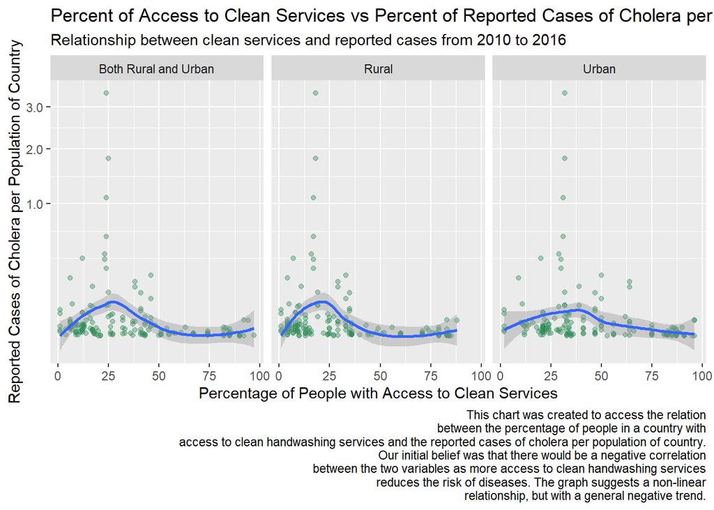

This chart was created to access the relation between the percentage of people in a country with access to clean handwashing services and the reported cases of cholera per population of country. Our initial belief was that there would be a negative correlation between the two variables as more access to clean handwashing services reduces the risk of diseases. The graph suggests a non-linear relationship, but with a general negative trend.

## Chart 2

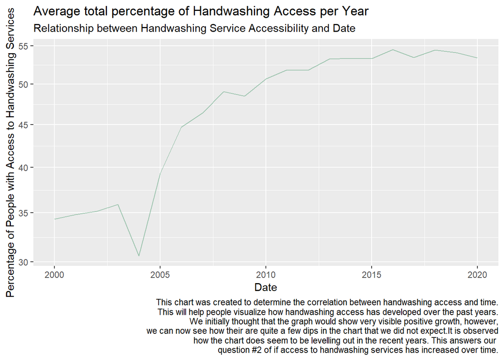

This chart was created to determine the correlation between handwashing access and time. This will help people visualize how handwashing access has developed over the past years. We initially thought that the graph would show very visible positive growth, however, we can now see how their are quite a few dips in the chart that we did not expect.It is observed how the chart does seem to be levelling out in the recent years. This answers our question #2 of if access to handwashing services has increased over time.

## Chart 3

```
## # A tibble: 5 × 2
##   country_type   Percent
##   <chr>            <dbl>
## 1 extremely poor    25.2
## 2 poor              35.9
## 3 slightly poor     67.9
## 4 average           71.7
## 5 rich              86.2
```

```
## # A tibble: 5 × 2
##   country_type   Percent
##   <chr>            <dbl>
## 1 extremely poor    25.2
## 2 poor              35.9
## 3 slightly poor     67.9
## 4 average           71.7
## 5 rich              86.2
```

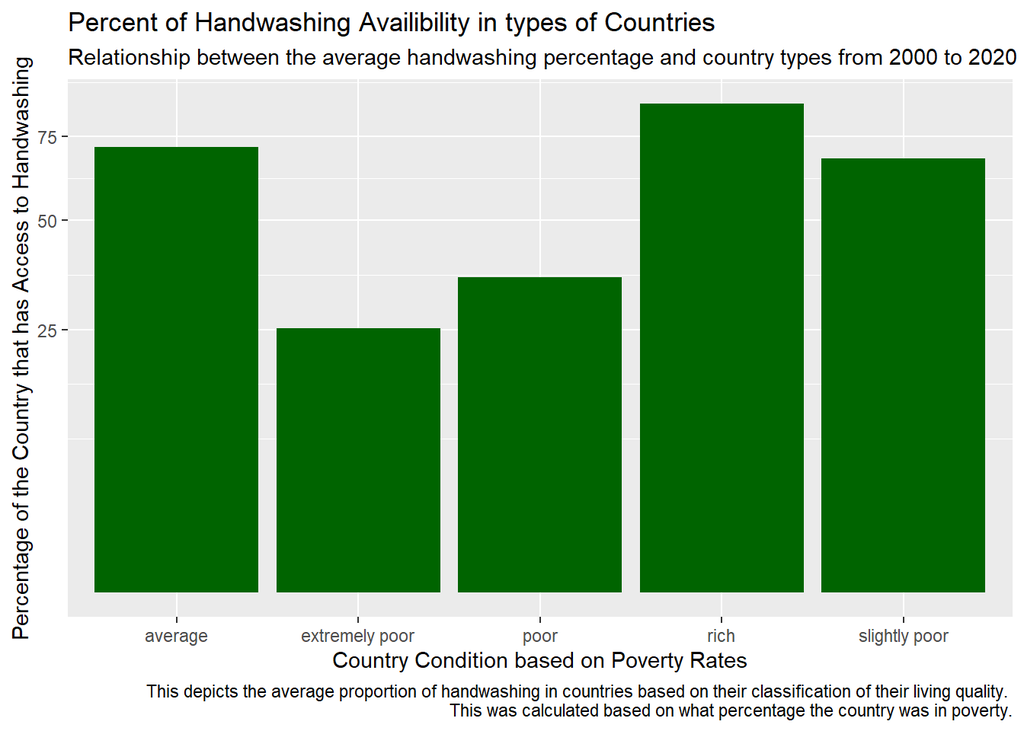

The reason for working on this chart is to delve into how poverty can affect access to clean water services. This problem that stems from poverty can result in diseases such as cholera, or symptoms of diarrhea, and other factors. This may also result in health problems, and thus more money spent on those services, continuing and increasing the cycle of poverty. From the graph and data that I analyzed, the companies with the lowest poverty rates ended up having the most access to handwashing. The divide between the average of the lowest poverty rate countries and highest poverty rates was 86.17% compared to 25.21% which is a really big gap. Thus, there needs to be a lot more emphasis on countries that have high poverty rates. The data was not surprising in terms of the condition of the countries and their percentages, but the gap between each condition was alarming to see, especially at the extreme ends of each side.